# Analysis of OMICS data, practical 8

Transcriptomics part 2

Author

Affiliation

Eszter Ari

Eötvös Loránd University, Budapest & Biological Research Centre, Szeged

Published

April 10, 2026

**The description of the practical is based on [Altuna Akalin’s book: Computational Genomics with R](https://compgenomr.github.io/book/)**

# Description of the practical

In this practical, we will use the `RStudio Server` available here: https://rstudio.dlab.elte.hu/. Please log in using the same *username* and *password* as you use with `ssh` login to the server.

**After this lab, you will be able to:**

- To normalize the raw read counts using different methods
- To explore and visualize count data
- To do differential gene expression analysis
- To visualize and understand the results

The **Tasks** and **Questions** will be denoted by boxes, as follows:

**NoteT0 Q0**

Questions to solve go here.

## The dataset and the environment

The original count tables are from the [recount2 database](https://jhubiostatistics.shinyapps.io/recount/). It uses the SRA project code [**SRP029880**](https://www.ncbi.nlm.nih.gov/sra/?term=SRP029880). The experimental setup, along with additional accessory information, can be found on the *NCBI Gene Expression Omnibus* under project code [**GSE50760**](https://www.ncbi.nlm.nih.gov/geo/query/acc.cgi?acc=GSE50760).

### **Task 1**: Setting up the environment

- Create a directory named Transcriptomics_part_2 for the project.
- Create a new `RStudio server` *Project*.
- Open a new R Script file and save it.

# Different normalization schemes

Comparison of the common normalization methods[^1]

| **Normalization method** | **Description** | **Accounted factors** | **Recommendations for use** |
| --- | --- | --- | --- |
| **CPM** (counts per million) | counts scaled by the total number of reads | sequencing depth | gene count comparisons between replicates of the same sample group; **NOT for within-sample comparisons or DE analysis** |
| **TPM** (transcripts per kilobase million) | counts per length of transcript (kb) per million reads mapped | sequencing depth and gene length | gene count comparisons within a sample or between samples of the same sample group; **NOT for DE analysis** |
| **RPKM/FPKM** (reads/fragments per kilobase of exon per million reads/fragments mapped) | similar to TPM | sequencing depth and gene length | gene count comparisons between genes within a sample; **NOT for between-sample comparisons or DE analysis** |
| DESeq2’s **median of ratios** | counts divided by sample-specific size factors determined by the median ratio of gene counts relative to the geometric mean per gene | sequencing depth and RNA composition | gene count comparisons between samples and for **DE analysis**; **NOT for within-sample comparisons** |
| edgeR’s **trimmed mean of M values (TMM)** | uses a weighted trimmed mean of the log expression ratios between samples | sequencing depth and RNA composition | gene count comparisons between and within samples, and for **DE analysis** |

## Computing different normalization schemes in `R`

**Important**

We try out multiple normalization methods to get familiar with them and assess their impact on the counts. During a normal analysis, we apply only a **single** normalization method!

Here, we will use a subset of the RNA-seq count table from a colorectal cancer study. We have filtered the original count table to include only protein-coding genes (to improve calculation speed) and selected five metastasized colorectal cancer samples and five normal colon samples. There is an additional column *width* that contains the length of the corresponding gene in base pairs. The length of the genes is important to compute *RPKM* and *TPM* values.

## Raw read **counts**

### **Task 2**: Read the CSV (comma-separated value) table file (that contains the raw read counts and the length of the genes for cases and control experiments) as a *data.frame* in `R`.

- You can find the file here: /shared/OMICS/practical_08/colorectal_cancer_RNA-Seq_counts.csv
- Name the *data.frame* to “counts”.
- Make the first column *rownames*.

**NoteT2 Q1**

Copy the code you have used to read the table in.

**NoteT2 Q2**

What is the size of the table? (Nr. of rows and columns)?

**NoteT2 Q3**

How many replicates are there as “case” and as “control”?

Let’s check the *head* and the *sum of each column* of the **counts** table:

```r
head(counts)
```

```
         CASE_1 CASE_2 CASE_3 CASE_4 CASE_5 CTRL_1 CTRL_2 CTRL_3 CTRL_4 CTRL_5
TSPAN6   776426 371725 612244 456147 513335 559544 489653 332084 238516 634115
TNMD       1483    806   2995    297   1095   4631   1884   4484   1961   3976
DPM1     364919 274342 248740 371045 325628 211173 123204 113606  67338 198331
SCYL3    103601  97625  98387 117366 101943 160847 106890 106938  64928 101515
C1ORF112  90805  59235  61460 108892  44839  52308  34236  38087  18522  58008
FGR       57081 145623  26800 168519 158882  59723  24483  21608  18654  23682
          width
TSPAN6    12883
TNMD      15084
DPM1      23689
SCYL3     44637
C1ORF112 192074
FGR       23214
```

```r
colSums(counts)
```

```
    CASE_1     CASE_2     CASE_3     CASE_4     CASE_5     CTRL_1     CTRL_2
5835484126 5385234092 5186983103 7188715474 6828934042 6686566581 5390529841
    CTRL_3     CTRL_4     CTRL_5      width
5211852556 3607313731 5440016265 1334678339
```

Let’s summarize the distribution of the $log_{2}$ counts with boxplots.

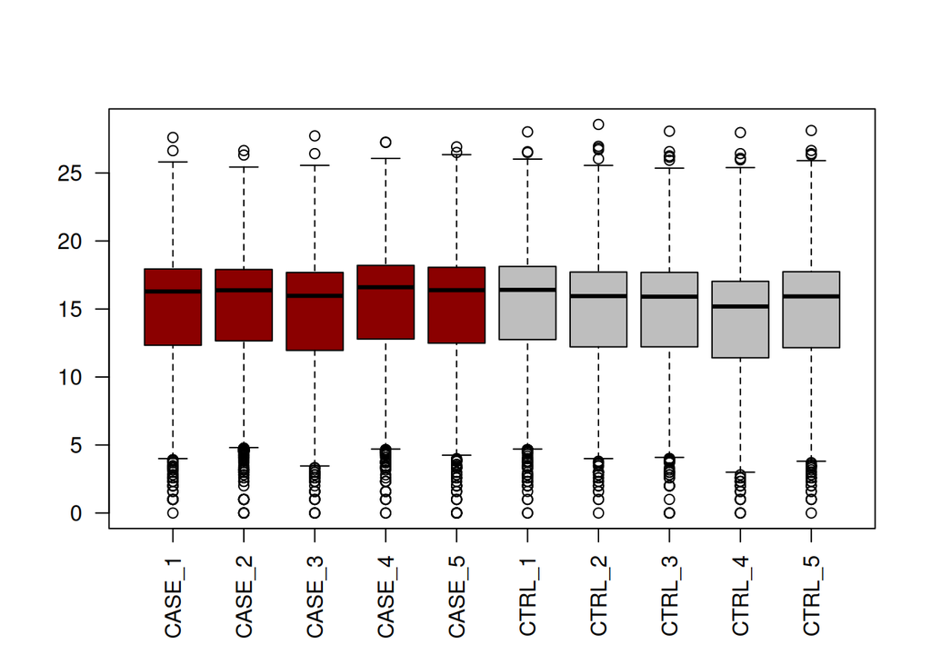

```r
boxplot(x = log2(counts[, 1:10]), # including read count only
        col = c(rep("darkred", 5), # control samples with red
                rep("gray", 5)), # case samples with gray
        las = 2) # vertical axis labels
```

## **CPM** (Counts Per Million) normalization

**CPM** of a single gene from a single sample:

$CPM = \frac{\text{Nr. of read counts of the gene × } 10^{6}}{\text{Total nr. of counted reads}}$

**CPM** of all genes of all samples (excluding the *width* column):

```r
cpm <- apply(X = counts[, 1:10],
             MARGIN = 2,
             FUN = function(x) x/sum(as.numeric(x)) * 10^6)

# check the head
head(cpm)
```

```
              CASE_1     CASE_2      CASE_3      CASE_4     CASE_5     CTRL_1
TSPAN6   133.0525426 69.0267115 118.0347011 63.45319990 75.1705899 83.6818109
TNMD       0.2541349  0.1496685   0.5774069  0.04131475  0.1603471  0.6925826
DPM1      62.5344859 50.9433750  47.9546579 51.61492360 47.6835767 31.5816791
SCYL3     17.7536255 18.1282742  18.9680587 16.32642166 14.9280985 24.0552454
C1ORF112  15.5608340 10.9995218  11.8488915 15.14762970  6.5660321  7.8228489
FGR        9.7817077 27.0411643   5.1667799 23.44215745 23.2660030  8.9317887
             CTRL_2     CTRL_3     CTRL_4      CTRL_5
TSPAN6   90.8357832 63.7170750 66.1201154 116.5649088
TNMD      0.3495018  0.8603467  0.5436178   0.7308802
DPM1     22.8556382 21.7976235 18.6670761  36.4577954
SCYL3    19.8292196 20.5182320 17.9989890  18.6607898
C1ORF112  6.3511382  7.3077662  5.1345687  10.6632034
FGR       4.5418541  4.1459346  5.1711610   4.3532958
```

Check the counts for all samples after **CPM** normalization. Notice that the sums of the samples are all equal to 10<sup>6</sup>.

```r
colSums(cpm)
```

```
CASE_1 CASE_2 CASE_3 CASE_4 CASE_5 CTRL_1 CTRL_2 CTRL_3 CTRL_4 CTRL_5
 1e+06  1e+06  1e+06  1e+06  1e+06  1e+06  1e+06  1e+06  1e+06  1e+06
```

### **Task 3**: Exploring the **CPM** values

**NoteT3 Q1**

Summarize the distribution of the $log_{2}$ **CPM** normalized counts with boxplots.

**NoteT3 Q2**

What is the mean of the **CPM** values of “CASE_1”? Is it lower or higher than the mean of the original counts of “CASE_1”?

## **RPKM** (Reads Per Kilo base of transcript per Million mapped reads) normalization

**RPKM** of a single gene from a single sample:

$RPKM = \frac{\text{Nr. of read counts of the gene × } 10^{3} × 10^{6}}{\text{Total nr. of counted reads × Gene length}}$

**RPKM** of all genes of all samples:

```r
# create a vector of gene lengths
geneLengths <- counts$width

# compute rpkm
rpkm <- apply(X = counts[, 1:10],
              MARGIN = 2,
              FUN = function(x) 10^9 * x / geneLengths / sum(as.numeric(x)))

# check the head
head(rpkm)
```

```
              CASE_1      CASE_2     CASE_3      CASE_4     CASE_5     CTRL_1
TSPAN6   10.32776081 5.357968757 9.16205085 4.925343468 5.83486687 6.49552207
TNMD      0.01684798 0.009922336 0.03827943 0.002738979 0.01063028 0.04591505
DPM1      2.63981113 2.150507621 2.02434285 2.178856161 2.01289952 1.33317907
SCYL3     0.39773339 0.406126625 0.42494027 0.365759833 0.33443328 0.53890820
C1ORF112  0.08101479 0.057267105 0.06168920 0.078863509 0.03418491 0.04072831
FGR       0.42137106 1.164864492 0.22257172 1.009828442 1.00224016 0.38475871
             CTRL_2     CTRL_3     CTRL_4     CTRL_5
TSPAN6   7.05082537 4.94582589 5.13235390 9.04796312
TNMD     0.02317037 0.05703704 0.03603937 0.04845400
DPM1     0.96482073 0.92015803 0.78800608 1.53901792
SCYL3    0.44423280 0.45966871 0.40323026 0.41805654
C1ORF112 0.03306610 0.03804662 0.02673224 0.05551612
FGR      0.19565151 0.17859631 0.22276045 0.18752890
```

Check the counts for all samples after **RPKM** normalization. Notice that the sums of the samples are all different.

```r
colSums(rpkm)
```

```
  CASE_1   CASE_2   CASE_3   CASE_4   CASE_5   CTRL_1   CTRL_2   CTRL_3
158291.0 153324.2 161775.4 173047.4 172761.4 210032.6 301764.2 241418.3
  CTRL_4   CTRL_5
291674.5 252005.7
```

### **Task 4**: Exploring the **RPKM** values

**NoteT4 Q1**

Summarize the distribution of $log_{2}$ **RPKM**-normalized counts using boxplots.

**NoteT4 Q2**

Which samples have the lowest and the highest **RPKM** values on average? (Include the code in your answer as well.)

The above-mentioned normalization methods are also explained in this [StatQuest video](https://youtu.be/TTUrtCY2k-w?list=PLblh5JKOoLUJo2Q6xK4tZElbIvAACEykp).

None of the CPM, RPKM/FPKM (and TPM) metrics account for another important confounding factor when comparing expression levels of genes across samples: **library composition**, which may also be referred to as the **relative size of the compared transcriptomes**. This factor is not dependent on the sequencing technology; it is rather biological. For instance, when comparing transcriptomes across different tissues, some genes in one tissue can consume a large fraction of reads, whereas in the other tissue, they are not expressed at all. This kind of imbalance in the composition of compared transcriptomes can lead to wrong conclusions about which genes are actually differentially expressed. This consideration is addressed in two popular `R` packages: `DESeq2` (Love, Huber, and Anders 2014) and `edgeR` (Robinson, McCarthy, and Smyth 2010), each with a different algorithm. `edgeR` uses a normalization procedure called **Trimmed Mean of M-values (*TMM*)**. `DESeq2` implements a normalization procedure using **Median of Ratios**, which is obtained by finding the ratio of the log-transformed count of a gene divided by the average of the log-transformed values of the gene in all samples (geometric mean), and then taking the median of these values for all genes. The raw read count for each gene is finally divided by this value (the median of the ratios) to obtain normalized counts. In order to see a demonstration of `DESeq2`’s normalization method, see the **Differential expression analysis** section.

The normalization method of `DESeq2` is explained in this [StatQuest video](https://youtu.be/UFB993xufUU?list=PLblh5JKOoLUJo2Q6xK4tZElbIvAACEykp).

# Exploratory analysis of the *read count table*

A typical quality control, in this case, interrogating the RNA-seq experiment design, is to measure the similarity among samples in terms of the quantified expression level profiles across a set of genes. One important observation to make is whether the most similar samples to any given sample are its biological replicates. This can be computed using unsupervised clustering techniques such as hierarchical clustering and visualized as a *heatmap* with dendrograms. Another commonly applied technique is *Principal Component Analysis (PCA)*, which is visualized as a two-dimensional (or, in some cases, three-dimensional) *scatter plot*. PCA is a technique used to emphasize variation and bring out strong patterns in a dataset. It’s often used to make data easy to explore and visualize. See some detailed visual explanations [here](https://setosa.io/ev/principal-component-analysis/).

## Clustering the samples and the genes based on their expression levels

WWe can combine clustering and heatmap visualization of the results using the heatmap functions available in various `R` libraries. The basic `R` installation comes with the `stats::heatmap` function. However, there are other libraries available in [CRAN](https://cran.r-project.org/) (*e.g.*, `pheatmap` (Kolde 2019) and the `geom_tile` function of `ggplot2`) or [Bioconductor](https://bioconductor.org/) (*e.g.*, `ComplexHeatmap` (Gu, Eils, and Schlesner 2016)) that offer greater flexibility and more appealing visualizations.

The drawing and the interpretation of heatmaps are explained in this [StatQuest video](https://youtu.be/oMtDyOn2TCc?list=PLblh5JKOoLUJo2Q6xK4tZElbIvAACEykp).

Here, we demonstrate a heatmap using the `pheatmap` package and the previously calculated *RPKM* normalized read counts. As these matrices can be quite large, both computing the clustering and rendering the heatmaps can consume substantial resources and time. Therefore, a quick and informative way to compare samples is to select a subset of genes that are, for instance, most variable across samples, and use that subset to do the clustering and visualization.

Let’s select the top 100 most variable genes among the samples:

```r
# compute the variance of each gene across samples
V <- apply(rpkm, 1, var)

# sort the results by variance in decreasing order and select the top 100 genes
selectedGenes <- names(V[order(V, decreasing = T)][1:100])
```

Now we can quickly produce a heatmap where samples and genes are clustered:

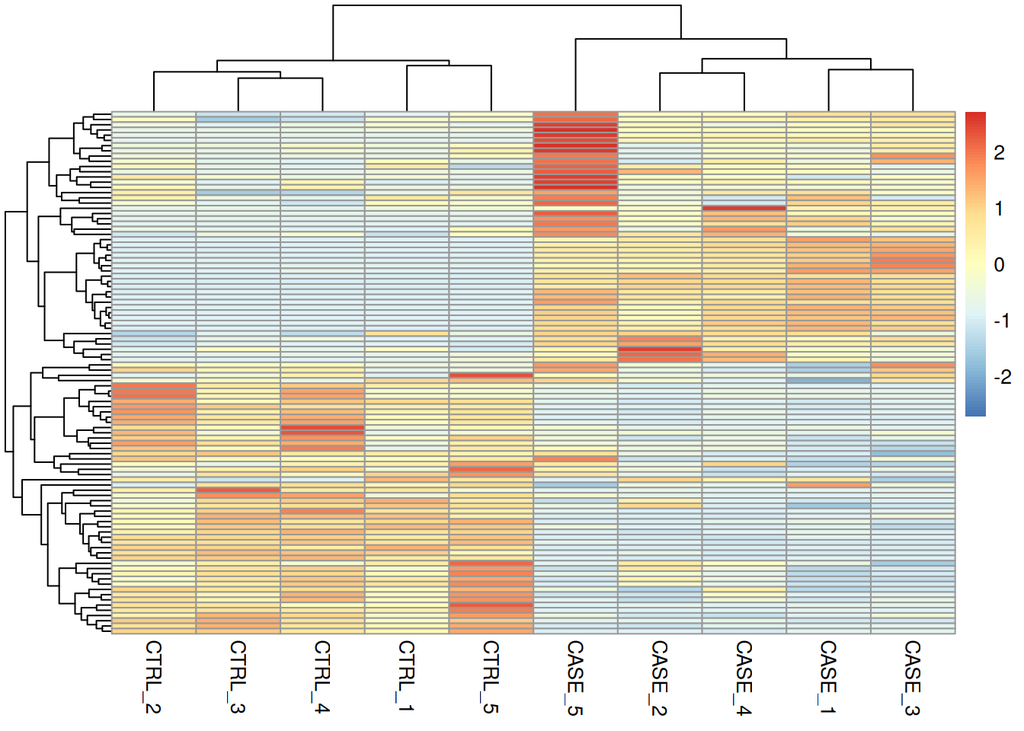

```r
library(pheatmap)

pheatmap(rpkm[selectedGenes, ], scale = 'row', show_rownames = FALSE)
```

**NoteT5 Q1**

Which one is the closest sample to “CASE_1”, based on the above clustering?

We can also overlay some annotation tracks to observe the clusters. Here, it is important to observe whether the replicates of the same sample cluster most closely together. Overlaying the heatmap with such an annotation and displaying sample groups in distinct colors quickly helps identify samples that don’t cluster as expected.

Reading the table that contains the description of the samples.

```r
colData <- read.csv(
  "/shared/OMICS/practical_08/colorectal_cancer_colData.csv",
  row.names = 1)
```

The content of the *colData* `data.frame`:

|  | source_name | group |
| --- | --- | --- |
| CASE_1 | metastasized cancer | CASE |
| CASE_2 | metastasized cancer | CASE |
| CASE_3 | metastasized cancer | CASE |
| CASE_4 | metastasized cancer | CASE |
| CASE_5 | metastasized cancer | CASE |
| CTRL_1 | normal colon | CTRL |
| CTRL_2 | normal colon | CTRL |
| CTRL_3 | normal colon | CTRL |
| CTRL_4 | normal colon | CTRL |
| CTRL_5 | normal colon | CTRL |

Creating the heatmap plot that contains some metadata.

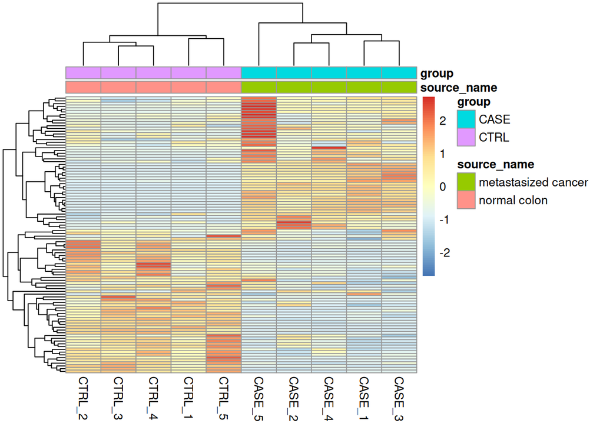

```r
pheatmap(rpkm[ selectedGenes, ],
         scale = 'row',
         show_rownames = FALSE,
         annotation_col = colData)
```

## **PCA** (Principal Component Analysis) of the samples based on the *RPKM* normalized counts of the top 100 most variable genes

If you need an explanation about the **PCA** method, please watch this [StatQuest video](https://youtu.be/HMOI_lkzW08?list=PLblh5JKOoLUJo2Q6xK4tZElbIvAACEykp).

Let’s make a **PCA** plot to see the clustering of replicates as a scatter plot in two dimensions.

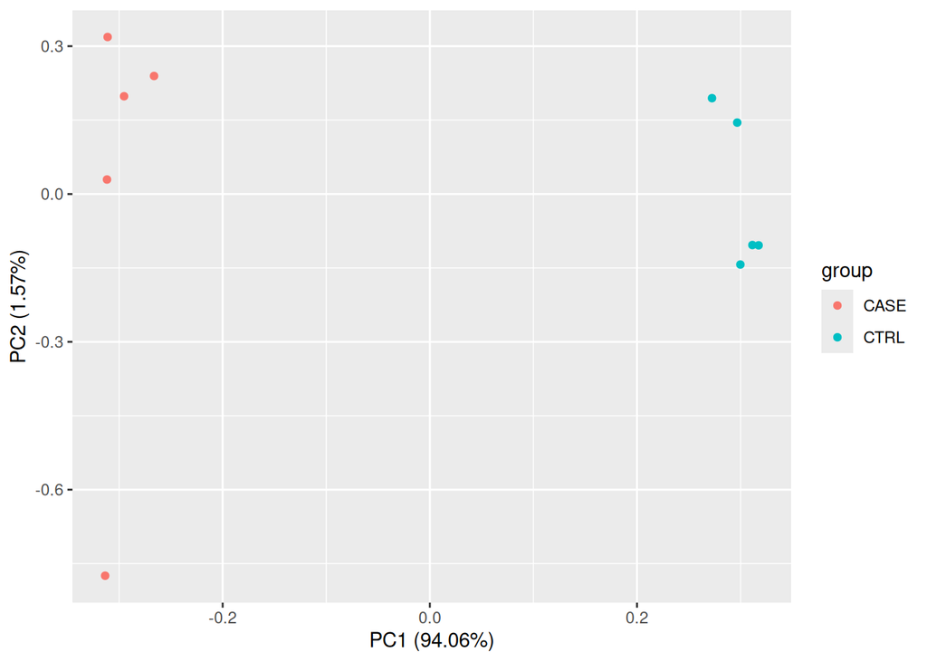

```r
library(stats)
library(ggplot2)
# ggfortify package is needed to let ggplot2 know about PCA data structure.
library(ggfortify)

# transpose the matrix
M <- t(rpkm[selectedGenes, ])

# transform the counts to log2 scale
M <- log2(M + 1)

# compute PCA
pcaResults <- prcomp(M)

# plot PCA results making use of ggplot2's autoplot function
autoplot(pcaResults,
         data = colData,
         colour = 'group')
```

We should observe whether the samples from the case group (*CASE*) and the control group (*CTRL*) can be split into two distinct clusters on the scatter plot of the first two largest principal components (*PC1* and *PC2*).

### **Task 6**: PCA proportion of variance

**NoteT6 Q1**

Use the `summary` function to summarize the PCA results to observe the contribution of the principal components in the explained variation. Copy the code you used.

**NoteT6 Q2**

What proportion of variance is explained by the 1<sup>st</sup> principal component (PC1)?

# Differential expression analysis

*Differential expression analysis* allows us to test tens of thousands of hypotheses (one test per gene) against the null hypothesis that the gene’s activity remains the same across two conditions. There are multiple limiting factors that influence the power to detect genes with real changes between two biological conditions. Among these are the limited number of biological replicates, non-normality in the distribution of read counts, and greater measurement uncertainty for lowly expressed genes than for highly expressed genes (Love, Huber, and Anders 2014). Tools such as `edgeR` and `DESeq2` address these limitations by using sophisticated statistical models to maximize the amount of knowledge that can be extracted from noisy datasets.

An external video about differential expression analysis is available [here](https://youtu.be/5tGCBW3_0IA).

## `DESeq2`

1. Normalizes the read counts by computing size factors, which addresses the differences not only in the library sizes, but also in the library compositions.
2. FFor each gene, it estimates the dispersion of the gene across biological replicates. The dispersion value computed by `DESeq2` is equal to the squared coefficient of variation (variation divided by the mean).
3. A line is fitted across the dispersion estimates of all genes computed in 2) versus the mean normalized counts of the genes.
4. Dispersion values of each gene are shrunken towards the fitted line in 3).
5. A *Generalized Linear Model (GLM)* is fitted, accounting for additional confounding variables related to the experimental design, such as sequencing batches, treatment, temperature, patient age, sequencing technology, *etc*.
6. For a given contrast (*e.g.*, treatment type: drug-A *versus* untreated), a test for differential expression is carried out against the null hypothesis that the log fold change of the normalized counts of the gene in the given pair of groups is exactly zero.
7. Adjusts *p*-values for multiple testing.

In order to carry out a differential expression analysis using `DESeq2`, three kinds of inputs are necessary:

1. The **read count table** must contain *raw* read counts as integers, not processed by any normalization technique. The rows represent features (*e.g.*, genes, transcripts, genomic intervals) and columns represent samples.
2. A **colData** table: this table describes the experimental design.
3. A **design formula**: this formula describes the variable of interest in the analysis (*e.g.*, treatment status) along with (optionally) other covariates (*e.g.*, batch, temperature, sequencing technology).

Let’s define these inputs:

```r
# remove the 'width' column and convert the data.frame to a matrix
countData <- as.matrix(counts[, 1:10])

# define the experimental setup:
# we already have the colData variable

# define the design formula based on the "group" column of colData
designFormula <- "~ group"
```

We are now ready to run `DESeq2`.

```r
library(DESeq2)

# create a DESeq dataset object from the count matrix and the colData
dds <- DESeqDataSetFromMatrix(countData = countData,
                              colData = colData,
                              design = as.formula(designFormula))

# print dds object to see the contents
print(dds)
```

```
class: DESeqDataSet
dim: 19719 10
metadata(1): version
assays(1): counts
rownames(19719): TSPAN6 TNMD ... MYOCOS HSFX3
rowData names(0):
colnames(10): CASE_1 CASE_2 ... CTRL_4 CTRL_5
colData names(2): source_name group
```

The *DESeqDataSet* object contains all the information about the experimental setup, the read counts, and the design formulas. Certain functions can be used to access this information separately: `rownames(dds)` shows which features are used in the study (*e.g.,* genes), `colnames(dds)` displays the studied samples, `counts(dds)` displays the count table, and `colData(dds)` displays the experimental setup.

Remove genes that have almost no information in any of the given samples.

```r
# For each gene, we count the total number of reads for that gene in all samples
# and remove those that don't have at least 1 read.
dds <- dds[rowSums(counts(dds)) > 1, ]
```

Now, we can use the `DESeq` function from the `DESeq2` package, which is a wrapper that implements estimation of size factors to normalize the counts, estimation of dispersion values, and fitting a *GLM model* based on the experimental design formula. This function returns a *DESeqDataSet* object, an updated version of the *dds* variable we pass to the function as input.

```r
dds <- DESeq(dds)
```

## Diagnostic plots

At this point, before proceeding with any downstream analysis and jumping to conclusions about the biological insights that are achievable with the experimental data at hand, it is important to run additional diagnostic tests to improve our confidence in the data quality and experimental setup.

### **PCA** plot

A final diagnosis is to check the biological reproducibility of the sample replicates in a **PCA** plot or a *heatmap*. Normalized counts can be transformed using the `DESeq2::rlog` function, and the `DESeq2::plotPCA` can be readily used to plot the PCA results.

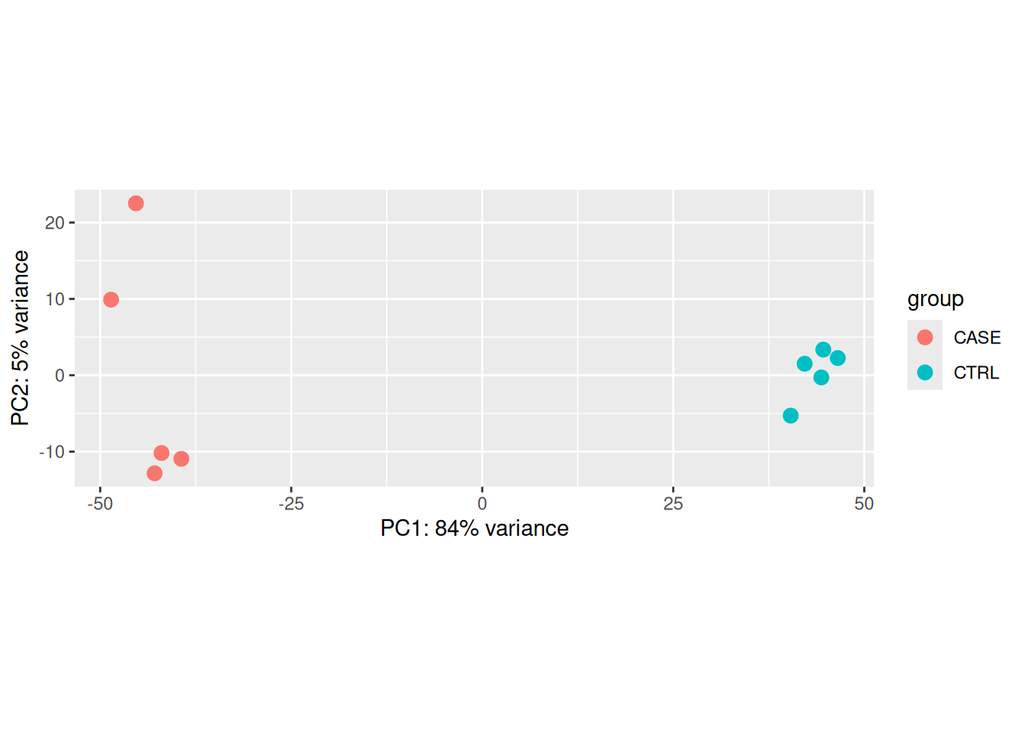

```r
rld <- rlog(dds)

plotPCA(rld,
        ntop = 500,
        intgroup = 'group')
```

### **Task 7**: Understanding the PCA plot

**NoteT7 Q1**

Why is this PCA plot a bit different from the previous PCA plot?

### The **RLE** (Relative Log Expression) plot

The *RLE* plot is useful for determining whether the data at hand require normalization (Gandolfo and Speed 2018). Sometimes, even the datasets normalized using the explained methods above may need further normalization due to unforeseen sources of variation that might stem from the library preparation, the person who carries out the experiment, the date of sequencing, the temperature changes in the laboratory at the time of library preparation, and so on and so forth. An *RLE plot* is a quick diagnostic that can be applied to raw or normalized count matrices to determine whether further processing is required.

Let’s generate *RLE plots* of raw counts and normalized counts using the `EDASeq` package (Risso et al. 2011).

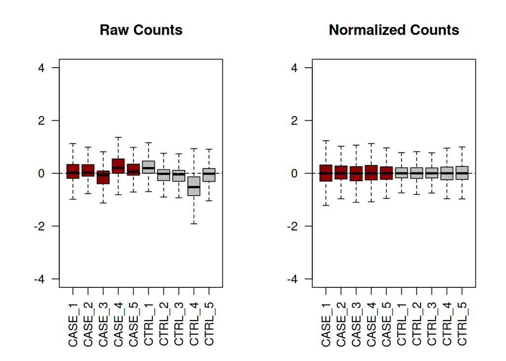

```r
library(EDASeq)

# plot the 2 plots next to each other
par(mfrow = c(1, 2))

# plot 1 is using the raw read counts
plotRLE(countData,
        outline = FALSE,
        ylim = c(-4, 4),
        col = c(rep("darkred", 5), rep("gray", 5)),
        main = 'Raw Counts',
        las = 2)

# plot 2 is using the normalized counts
plotRLE(counts(dds, normalized = TRUE),
        outline = FALSE,
        ylim = c(-4, 4),
        col = c(rep("darkred", 5), rep("gray", 5)),
        main = 'Normalized Counts',
        las = 2)
```

Here, the *RLE plot* comprises boxplots, where each boxplot represents the distribution of the *relative log expression* of the genes expressed in the corresponding sample. Each gene’s expression is divided by the median expression value of that gene across all samples. Then this is transformed to a log scale, which gives the relative log expression value for a single gene. The *RLE* values for all the genes from a sample are visualized as a boxplot.

Ideally, the boxplots are centered around the horizontal zero line and are as tightly distributed as possible (Risso et al. 2014). From the plots we made for the raw and normalized count data, we can observe that the normalized dataset has improved upon the raw count data across all samples. However, in some cases, it is important to visualize **RLE** plots in combination with other diagnostic plots such as **PCA** plots, heatmaps, and correlation plots to see if there is more unwanted variation in the data, which can be further accounted for using packages such as `RUVseq` (Risso et al. 2014) and `sva` (Leek et al. 2012).

## Differentially expressed genes

Now, we can compare and contrast the samples based on different variables of interest. In this case, we currently have only one variable: the `group` variable that determines whether a sample belongs to the CASE group or the CTRL group.

```r
# compute the contrast for the 'group' variable where 'CTRL' samples are used as the control group.
DEresults <- results(dds,
                     contrast = c("group", 'CASE', 'CTRL'))

# sort results by increasing p-value
DEresults <- DEresults[order(DEresults$pvalue), ]
```

Thus, we have obtained a table of the differential expression status of case samples relative to control samples.

It is important to note that the sequence of the elements in the *contrast* argument determines which group of samples is used as the *control*. This impacts how the results are interpreted; for instance, if a gene is found *up-regulated* (has a *positive* $log_{2}$ fold change), its up-regulation status is only relative to the factor provided as the *control*. In this case, we used samples from the *CTRL* group as *controls* and contrasted the samples from the *CASE* group with them. Thus, genes with a positive $log_{2}$ fold change are called up-regulated in the case samples with respect to the control, while genes with a negative $log_{2}$ fold change are down-regulated in the case samples. Whether the deregulation is significant or not warrants an assessment of the adjusted *p*-values.

Let’s have a look at the contents of the `DEresults` table.

```r
# shows a summary of the results
print(DEresults)
```

```
log2 fold change (MLE): group CASE vs CTRL
Wald test p-value: group CASE vs CTRL
DataFrame with 19097 rows and 6 columns
            baseMean log2FoldChange     lfcSE       stat       pvalue
           <numeric>      <numeric> <numeric>  <numeric>    <numeric>
CYP2E1       4829889        9.36024  0.215223    43.4909  0.00000e+00
FCGBP       10349993       -7.57579  0.186433   -40.6355  0.00000e+00
ASGR2         426422        8.01830  0.216207    37.0863 4.67898e-301
GCKR          100183        7.82841  0.233376    33.5442 1.09479e-246
APOA5         438054       10.20248  0.312500    32.6479 8.58227e-234
...              ...            ...       ...        ...          ...
CCDC195      20.4981      -0.215607   2.89255 -0.0745386           NA
SPEM3        23.6370     -22.154753   3.02785 -7.3169989           NA
AC022167.5   21.8451      -2.056240   2.89545 -0.7101618           NA
BX276092.9   29.9636       0.407326   2.89048  0.1409199           NA
ETDC         22.5675      -1.795274   2.89421 -0.6202983           NA
                   padj
              <numeric>
CYP2E1      0.00000e+00
FCGBP       0.00000e+00
ASGR2      2.87741e-297
GCKR       5.04945e-243
APOA5      3.16669e-230
...                 ...
CCDC195              NA
SPEM3                NA
AC022167.5           NA
BX276092.9           NA
ETDC                 NA
```

The first three lines of this output show the contrast and the statistical test used to compute these results, along with the dimensions of the resulting table (number of columns and rows). Below these lines is the actual table with 6 columns:

- **baseMean** represents the average normalized expression of the gene across all considered samples.
- **log2FoldChange** represents the base-2 logarithm of the fold change of the normalized expression of the gene in the given contrast.
- **lfcSE** represents the standard error of the $log_{2}$ fold change estimate, and
- **stat** is the statistic calculated in the contrast,
- which is translated into a **pvalue** and
- adjusted for multiple testing in the **padj** column.

You can read about the correction of *p*-values for multiple testing [here](https://towardsdatascience.com/an-overview-of-methods-to-address-the-multiple-comparison-problem-310427b3ba92) and/or watch a [Statquest video](https://youtu.be/K8LQSvtjcEo).

### **Task 8**: Figuring out the actual meaning of the results

**NoteT8 Q1**

What does the log2FoldChange of the gene in the first row in the above table mean? Is it highly expressed in the *CASE* or in the *CTRL* samples? How did you find out the answer? Copy the code here.

**NoteT8 Q2**

How many genes have been significantly differentially expressed based on their adjusted (multiple testing corrected) *p*-values (<0.05)? How did you calculate it? Copy the code here.

# Visualization of DE results

## MA plot

The **MA plot** is a scatter plot that shows the $log_{2}$ fold change of the genes on the *y*-axis and mean normalized counts on the *x*-axis. The **MA plot** is a useful diagnostic tool to visualize the distribution of the *p*-values and the $log_{2}$ fold changes. The genes that are significantly differentially expressed are usually located at the top or bottom of the plot, while the genes that are not significantly differentially expressed are located in the middle.

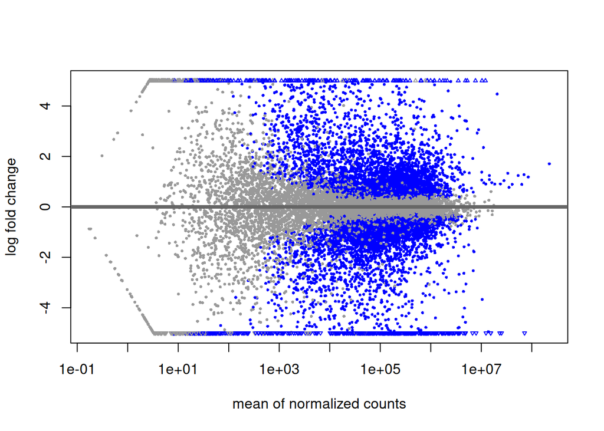

```r
par(mfrow = c(1, 1))
plotMA(object = dds, ylim = c(-5, 5))
```

## Volcano plot

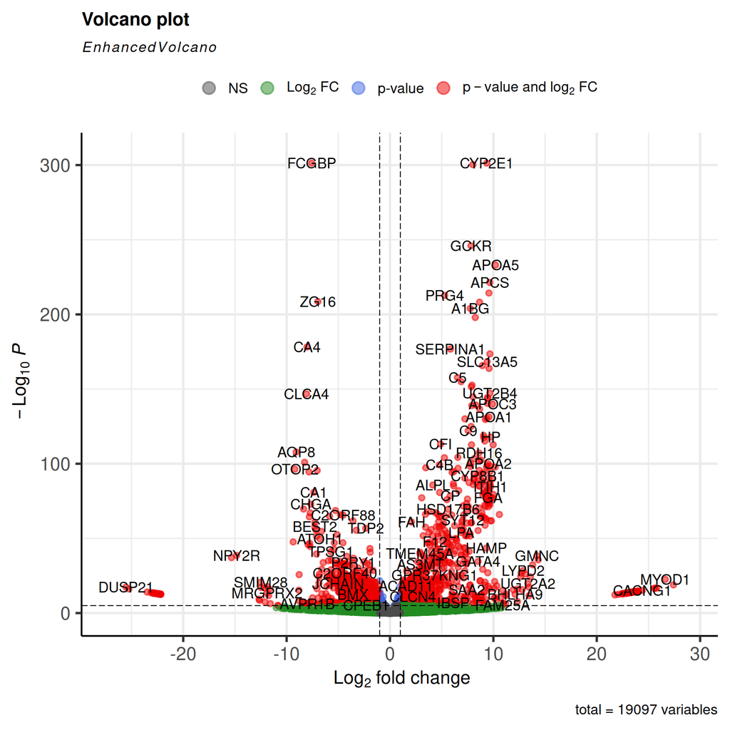

```r
library(EnhancedVolcano)

 EnhancedVolcano(DEresults,
    lab = rownames(DEresults),
    x = 'log2FoldChange',
    y = 'pvalue')
```

**NoteT9 Q1**

Which downregulated gene has the lowest *p*-value (the highest $-log_{10}p$)?

Which upregulated gene has the highest $log_{2}$ fold change?

## References

Gandolfo, Luke C., and Terence P. Speed. 2018. “RLE Plots: Visualizing Unwanted Variation in High Dimensional Data.” *PloS One* 13 (2): e0191629. https://doi.org/10.1371/journal.pone.0191629.

Gu, Zuguang, Roland Eils, and Matthias Schlesner. 2016. “Complex Heatmaps Reveal Patterns and Correlations in Multidimensional Genomic Data.” *Bioinformatics (Oxford, England)* 32 (18): 2847–49. https://doi.org/10.1093/bioinformatics/btw313.

Kolde, Raivo. 2019. *Pheatmap: Pretty Heatmaps*. https://CRAN.R-project.org/package=pheatmap.

Leek, Jeffrey T., W. Evan Johnson, Hilary S. Parker, Andrew E. Jaffe, and John D. Storey. 2012. “The Sva Package for Removing Batch Effects and Other Unwanted Variation in High-Throughput Experiments.” *Bioinformatics* 28 (6): 882–83. https://doi.org/10.1093/bioinformatics/bts034.

Love, Michael I, Wolfgang Huber, and Simon Anders. 2014. “Moderated Estimation of Fold Change and Dispersion for RNA-Seq Data with DESeq2.” *Genome Biology* 15 (12). https://doi.org/10.1186/s13059-014-0550-8.

Risso, Davide, John Ngai, Terence P. Speed, and Sandrine Dudoit. 2014. “Normalization of RNA-Seq Data Using Factor Analysis of Control Genes or Samples.” *Nature Biotechnology* 32 (9): 896–902. https://doi.org/10.1038/nbt.2931.

Risso, Davide, Katja Schwartz, Gavin Sherlock, and Sandrine Dudoit. 2011. “GC-Content Normalization for RNA-Seq Data.” *BMC Bioinformatics* 12 (December): 480. https://doi.org/10.1186/1471-2105-12-480.

Robinson, Mark D., Davis J. McCarthy, and Gordon K. Smyth. 2010. “edgeR: A Bioconductor Package for Differential Expression Analysis of Digital Gene Expression Data.” *Bioinformatics (Oxford, England)* 26 (1): 139–40. https://doi.org/10.1093/bioinformatics/btp616.

## Footnotes

[^1]: source: https://hbctraining.github.io/DGE_workshop/lessons/02_DGE_count_normalization.html